# Homework 2

### CSS 581

## Yasmine Subbagh

**Step 1: Getting Code to Run**

I had a few challenges starting out just to get the code to run. Luckily, someone in the discord was kind enough to supply the requirments for the project. I created a virtual enviroment to avoid conflicts with other more up to date packages I have. After downloading all the neccessary packages and correct versions, some modifications to the syntax and logic of the code needed to be modified to run. After everything was running properly and running the neccesary files I got the images below for the 4 original cusines.

```python
# just for show, code is now modified to show all cusinies, but this created the orignial 4 clusters seen in the images below.
# but you can comment out the new code and uncomment the old code to get this same result.
!python3 ./Flavor-Network-master/code/recipe_clustering.py
```

[output not shown]

[figure not shown]

**Part 1: Clustering ALL cuisines**

Next the code needed to be modified to cluster all of the cuisines.

All that needed to be modified was the sublist that grabs cuisine data, while this was previsouly 4 hard coded values, it now it parsed to find all the unique cuisine values.

Next was creating enough colors for all the cusisines, this was simple and again instead of the 4 hard coded values, a random list of colors (which were in RGB and then had to be translated into HEX) was generated by the length of the cuisine list.

Below are the results of the graphs, as images, but they can be accessed to be interactive within the graph directory of the code base.

```python
# same file, but this is modified to run all the cuisines.
!python3 ./Flavor-Network-master/code/recipe_clustering.py
```

```
(5622, 236) [0, 191, 624, 825, 972, 1383, 1581, 2002, 2279, 2443, 2563, 2791, 2969, 3310, 3596, 3613, 3800, 4002, 4186, 4544, 4810, 4903, 5062, 5246, 5530, 5622]
(3814, 1107) [0, 68, 488, 689, 836, 1246, 1352, 1401, 1676, 1806, 1926, 1932, 1976, 2314, 2600, 2617, 2804, 3006, 3190, 3548, 3814, 3814, 3814, 3814, 3814, 3814]
(3814, 1107) [0, 68, 488, 689, 836, 1246, 1352, 1401, 1676, 1806, 1926, 1932, 1976, 2314, 2600, 2617, 2804, 3006, 3190, 3548, 3814, 3814, 3814, 3814, 3814, 3814]
(5622, 236) [0, 191, 624, 825, 972, 1383, 1581, 2002, 2279, 2443, 2563, 2791, 2969, 3310, 3596, 3613, 3800, 4002, 4186, 4544, 4810, 4903, 5062, 5246, 5530, 5622]
```

[figure not shown]

**Part 2: Apply PCA analysis**

apply PCA analysis and measure how many components are required to explain 95% variability in the data? List down what percentage of variability is explained by each component.

We will be doing this with both the taste / flavor data and the ingredients dataset.

```python
# first import the needed libraries
import numpy as np
import pandas as pd
from sklearn.decomposition import PCA
from sklearn.preprocessing import StandardScaler
from sklearn.model_selection import train_test_split
from sklearn.cluster import KMeans
from sklearn.metrics import silhouette_score
from sklearn.cluster import DBSCAN, AgglomerativeClustering
from sklearn import metrics
from sklearn.datasets import make_blobs
from sklearn import datasets
from sklearn.mixture import GaussianMixture
import matplotlib.pyplot as plt
import seaborn as sns
from bokeh.plotting import figure, show, output_file, save
from bokeh.models import HoverTool, ColumnDataSource
from bokeh.palettes import Category20, Category20c, Turbo256
```

```python
# import the dataset
yum_ingr = pd.read_pickle('Flavor-Network-master/data/yummly_ingr.pkl')
yum_ingrX = pd.read_pickle('Flavor-Network-master/data/yummly_ingrX.pkl')
yum_tfidf = pd.read_pickle('Flavor-Network-master/data/yum_tfidf.pkl')
# make copies
df_ingr = yum_ingrX.copy() # the ingrredient files
df_taste = yum_tfidf.copy() # the taste / flavor file (dataset)

#get the cusisines
all_cuisines = yum_ingr['cuisine'].unique()

#mix the data
df_ingr['cuisine'] = yum_ingr['cuisine']
df_taste['cuisine'] = yum_ingr['cuisine']
```

Next, we need to standardize the data before we can begin with the computations.

```python
# Separating out the features
xIngr = df_ingr.drop(columns=['cuisine']).values
xTaste = df_taste.drop(columns=['cuisine']).values

# Separating out the target
yIngr = df_ingr.loc[:,['cuisine']].values
yTaste = df_taste.loc[:,['cuisine']].values

# Standardizing the features
xIngr = StandardScaler().fit_transform(xIngr)
xTaste = StandardScaler().fit_transform(xTaste)
```

Next, we are going to want to project this standardization into a 2D dimension as the oringal data has many features (x columns)

```python
# first for the ingrdients
pcaIngr = PCA()
printCompIngr = pcaIngr.fit_transform(xIngr)
printDFingr = pd.DataFrame(data=printCompIngr, columns=[f'principal component {i+1}' for i in range(printCompIngr.shape[1])])

# second for the taste
pcaTaste = PCA()
printCompTaste = pcaTaste.fit_transform(xTaste)
printDFtaste = pd.DataFrame(data=printCompTaste, columns=[f'principal component {i+1}' for i in range(printCompTaste.shape[1])])

# concate the dataframes
fdfIngr = pd.concat([printDFingr, df_ingr[['cuisine']]], axis = 1)
fdfTaste = pd.concat([printDFtaste, df_taste[['cuisine']]], axis = 1)
```

Next, let's create a plot so we can visulize what we've just done.

```python
# first lets do the ingrdeients PCA Plot
fdfIngr['cuisine'] = df_ingr['cuisine']
source = ColumnDataSource(fdfIngr)

output_file("pca_ingr_plot.html")

# Create the Bokeh figure
p = figure(title="PCA Plot Ingredients (2 Components)",
           x_axis_label='Principal Component 1',
           y_axis_label='Principal Component 2',
           width=1200, height=800, tools="pan,wheel_zoom,box_zoom,reset,hover")

# Plot each cuisine in the PCA space with different colors
colors = Turbo256[::len(Turbo256)//len(all_cuisines)]
for i, cuisine in enumerate(all_cuisines):
    indicesToKeep = fdfIngr['cuisine'] == cuisine
    p.circle(
        x='principal component 1',
        y='principal component 2',
        source=ColumnDataSource(fdfIngr[indicesToKeep]),
        size=8, color=colors[i], legend_label=cuisine, alpha=0.6
    )

# hover tool
hover = HoverTool(tooltips=[("Cuisine", "@cuisine")])
p.add_tools(hover)

# legend
p.legend.title = 'Cuisines'
p.legend.label_text_font_size = "10pt"
p.legend.location = "top_right"
p.legend.orientation = "vertical"
p.legend.margin = 10

# Save and show the plot
save(p)
show(p)
```

Here is the image but a interactive version is in the graphs directory.

[figure not shown]

```python
# next, lets do the taste PCA Plot
fdfTaste['cuisine'] = df_taste['cuisine']
source = ColumnDataSource(fdfTaste)

output_file("pca_taste_plot.html")

# Create the Bokeh figure
p = figure(title="PCA Plot Taste (2 Components)",
           x_axis_label='Principal Component 1',
           y_axis_label='Principal Component 2',
           width=1200, height=800, tools="pan,wheel_zoom,box_zoom,reset,hover")

# Plot each cuisine in the PCA space with different colors
colors = Turbo256[::len(Turbo256)//len(all_cuisines)]
for i, cuisine in enumerate(all_cuisines):
    indicesToKeep = fdfTaste['cuisine'] == cuisine
    p.circle(
        x='principal component 1',
        y='principal component 2',
        source=ColumnDataSource(fdfTaste[indicesToKeep]),
        size=8, color=colors[i], legend_label=cuisine, alpha=0.6
    )

# hover tool
hover = HoverTool(tooltips=[("Cuisine", "@cuisine")])
p.add_tools(hover)

# legend
p.legend.title = 'Cuisines'
p.legend.label_text_font_size = "10pt"
p.legend.location = "top_right"
p.legend.orientation = "vertical"
p.legend.margin = 10

# Save and show the plot
save(p)
show(p)
```

Here is the image but a interactive version is in the graphs directory.

[figure not shown]

Lets see the variance ratio and how many of the components are needed to reach 95% of the variance.

```python
# first for the ingredient data
#get how many vairables needed for the 95% variance
tVarianceIngr = np.cumsum(pcaIngr.explained_variance_ratio_)
compNeedIngr = np.argmax(tVarianceIngr >= 0.95) + 1
print(f"Number of components requied to explain 95% of the variance for the ingredients: {compNeedIngr}")

# get the variance for each component
explained_variance_ingr = pcaIngr.explained_variance_ratio_ * 100
print("Percentage of variance explained by each component (ingredients):")
for i, variance in enumerate(explained_variance_ingr):
    print(f"Principal Component {i+1}: {variance:.2f}%")
```

```
Number of components requied to explain 95% of the variance for the ingredients: 208
Percentage of variance explained by each component (ingredients):
Principal Component 1: 2.15%
Principal Component 2: 1.69%
Principal Component 3: 1.28%
Principal Component 4: 1.19%
Principal Component 5: 1.10%
Principal Component 6: 0.92%
Principal Component 7: 0.92%
Principal Component 8: 0.86%
Principal Component 9: 0.83%
Principal Component 10: 0.80%
Principal Component 11: 0.79%
Principal Component 12: 0.77%
Principal Component 13: 0.74%
Principal Component 14: 0.73%
Principal Component 15: 0.71%
Principal Component 16: 0.70%
Principal Component 17: 0.68%
Principal Component 18: 0.67%
Principal Component 19: 0.66%
Principal Component 20: 0.65%
Principal Component 21: 0.64%
Principal Component 22: 0.63%
Principal Component 23: 0.63%
Principal Component 24: 0.62%
Principal Component 25: 0.62%
Principal Component 26: 0.61%
Principal Component 27: 0.60%
Principal Component 28: 0.60%
Principal Component 29: 0.59%
Principal Component 30: 0.59%
Principal Component 31: 0.58%
Principal Component 32: 0.58%
Principal Component 33: 0.58%
Principal Component 34: 0.57%
Principal Component 35: 0.57%
Principal Component 36: 0.57%
Principal Component 37: 0.56%
Principal Component 38: 0.56%
```

[output cut: 183 more lines]

```
Principal Component 222: 0.18%
Principal Component 223: 0.18%
Principal Component 224: 0.17%
Principal Component 225: 0.17%
Principal Component 226: 0.17%
Principal Component 227: 0.16%
Principal Component 228: 0.16%
Principal Component 229: 0.15%
Principal Component 230: 0.15%
Principal Component 231: 0.14%
Principal Component 232: 0.13%
Principal Component 233: 0.12%
Principal Component 234: 0.12%
Principal Component 235: 0.10%
Principal Component 236: 0.09%
```

```python
# first for the taste data
#get how many vairables needed for the 95% variance
tVarianceTaste = np.cumsum(pcaTaste.explained_variance_ratio_)
compNeedTaste = np.argmax(tVarianceTaste >= 0.95) + 1
print(f"Number of components requied to explain 95% of the variance for the ingredients: {compNeedTaste}")

# get the variance for each component
explained_variance_taste = pcaIngr.explained_variance_ratio_ * 100
print("Percentage of variance explained by each component for the taste:")
for i, variance in enumerate(explained_variance_taste):
    print(f"Principal Component {i+1}: {variance:.2f}%")
```

[output not shown]

[output cut: 183 more lines]

```
Principal Component 222: 0.18%
Principal Component 223: 0.18%
Principal Component 224: 0.17%
Principal Component 225: 0.17%
Principal Component 226: 0.17%
Principal Component 227: 0.16%
Principal Component 228: 0.16%
Principal Component 229: 0.15%
Principal Component 230: 0.15%
Principal Component 231: 0.14%
Principal Component 232: 0.13%
Principal Component 233: 0.12%
Principal Component 234: 0.12%
Principal Component 235: 0.10%
Principal Component 236: 0.09%
```

**Part 3: Use K-means to cluster the data points**

Firstly, we need to cluster the data using a variety of sets, this will be splitting the sets into 2 to k aka for us I will use 32 (30 total variations).

```python
k_values = range(2, 32)

# for elbow later
ssd_ingr = []
ssd_taste = []
silhouette_scores_ingr = []
silhouette_scores_taste = []

# Use PCA data from earlier
X_ingr = printCompIngr
X_taste = printCompTaste

# Loop over the different values of k
for k in k_values:
    kmeans_ingr = KMeans(n_clusters=k, random_state=42)
    kmeans_ingr.fit(X_ingr)
    ssd_ingr.append(kmeans_ingr.inertia_)

    kmeans_taste = KMeans(n_clusters=k, random_state=42)
    kmeans_taste.fit(X_taste)
    ssd_taste.append(kmeans_taste.inertia_)

    # Calculate silhouette scores
    silhouette_scores_ingr.append(silhouette_score(X_ingr, kmeans_ingr.labels_))
    silhouette_scores_taste.append(silhouette_score(X_taste, kmeans_taste.labels_))
```

Next we will plot all of the sum of squared distances and the silloutte scores in order to help us locate which k (number of clusters) is optimal for our datasets.

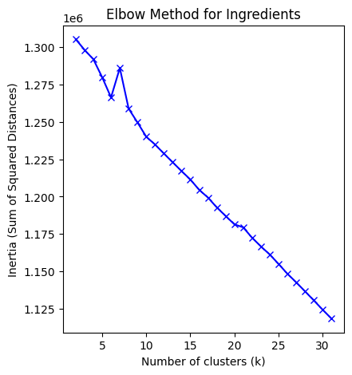

```python
# Plot the elbow graph for ingredients
plt.figure(figsize=(10, 5))

plt.subplot(1, 2, 1)
plt.plot(k_values, ssd_ingr, 'bx-')
plt.xlabel('Number of clusters (k)')
plt.ylabel('Inertia (Sum of Squared Distances)')
plt.title('Elbow Method for Ingredients')
```

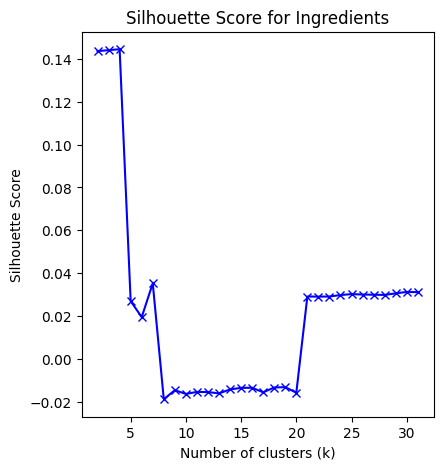

```python
# Plot the silhouette scores for ingredients
plt.figure(figsize=(10, 5))

plt.subplot(1, 2, 1)
plt.plot(k_values, silhouette_scores_ingr, 'bx-')
plt.xlabel('Number of clusters (k)')
plt.ylabel('Silhouette Score')
plt.title('Silhouette Score for Ingredients')
```

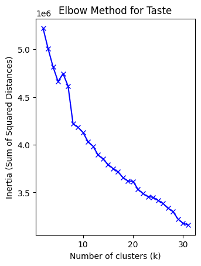

```python
# Plot the elbow graph for taste
plt.subplot(1, 2, 2)
plt.plot(k_values, ssd_taste, 'bx-')
plt.xlabel('Number of clusters (k)')
plt.ylabel('Inertia (Sum of Squared Distances)')
plt.title('Elbow Method for Taste')

plt.tight_layout()
plt.show()
```

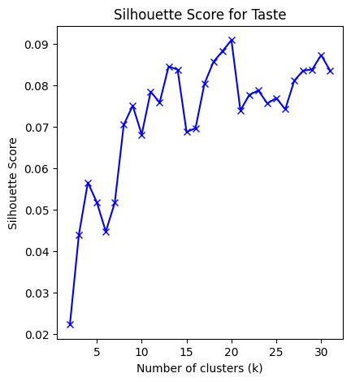

```python
# Plot the silhouette scores for taste
plt.figure(figsize=(10, 5))

plt.subplot(1, 2, 1)
plt.plot(k_values, silhouette_scores_taste, 'bx-')
plt.xlabel('Number of clusters (k)')
plt.ylabel('Silhouette Score')
plt.title('Silhouette Score for Taste')
```

However, it appears as though there might be a more prevelant optimal number of clustering with the taste data. At about 8 clusters the graph "elbows" off a bit, this could indicate that 8 clusters is optimal for the taste dataset. But, it appears from the silhouette score plot that the peak is at 20 clusters, this could indicate that 20 clusters is the optimal amount for the taste dataset. However, by comparing the two models together we will have to conclude that there is no clear optimal number (k) of clusters.

**Part 4: Cluster using DBSCAN, Hierarchical, and GMM clustering.**

We will start with DBSCAN, using the data from the PCA analysis.

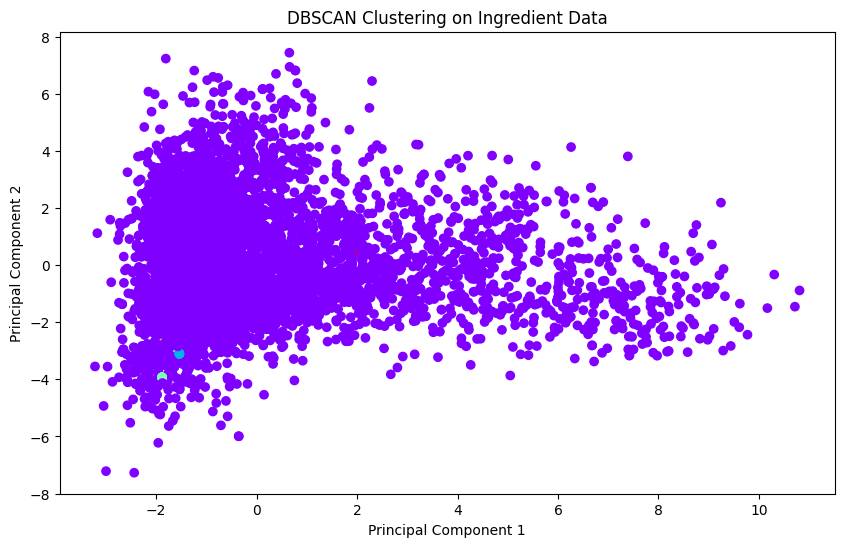

```
Number of clusters found by DBSCAN: 4
Indices of core samples:  [  57  115 1734 1758 1759 1773 1782 1819 1824 1905 1919 1924 1986 2703
 2855 3201 3217 3223 3232 3236 3247 3250 3259 3296 3305 3306 3317 3347
 3353 4178 4179 4180 4181 4182 4183 4184 4185 4186 4187 4428 4436 4440
 4469 4587 4627 5155 5156 5159 5162 5171 5181 5203 5210 5216 5229 5232
 5235 5236]
Copy of each core sample found by training:  [[-1.53806616 -3.1034039  -1.15491089 ... -0.22682363 -0.01131356
  -0.0585214 ]
 [-1.53806616 -3.1034039  -1.15491089 ... -0.22682363 -0.01131356
  -0.0585214 ]
 [-1.53806616 -3.1034039  -1.15491089 ... -0.22682363 -0.01131356
  -0.0585214 ]
 ...
 [-1.53806616 -3.1034039  -1.15491089 ... -0.22682363 -0.01131356
  -0.0585214 ]
 [-1.53806616 -3.1034039  -1.15491089 ... -0.22682363 -0.01131356
  -0.0585214 ]
 [-1.53806616 -3.1034039  -1.15491089 ... -0.22682363 -0.01131356
  -0.0585214 ]]
Labels:  [-1 -1 -1 ... -1 -1 -1]
Number of features seen during fit:  236
```

```python
# first for the ingredient data
dbscanIngr = DBSCAN(eps=0.5, min_samples=10).fit(printCompIngr)
labelsIngr = dbscanIngr.labels_
n_clusuters_ingr = len(set(labelsIngr)) - (1 if -1 in labelsIngr else 0)

#plot
plt.figure(figsize=(10,6))
plt.scatter(printCompIngr[:, 0], printCompIngr[:, 1], c=labelsIngr, cmap='rainbow')
plt.title('DBSCAN Clustering on Ingredient Data')
plt.xlabel('Principal Component 1')
plt.ylabel('Principal Component 2')
plt.show()

# attributes of the dbscan
print(f"Number of clusters found by DBSCAN: {n_clusuters_ingr}")
print("Indices of core samples: ", dbscanIngr.core_sample_indices_)
print("Copy of each core sample found by training: ", dbscanIngr.components_)
print("Labels: ", dbscanIngr.labels_)
print("Number of features seen during fit: ", dbscanIngr.n_features_in_)
```

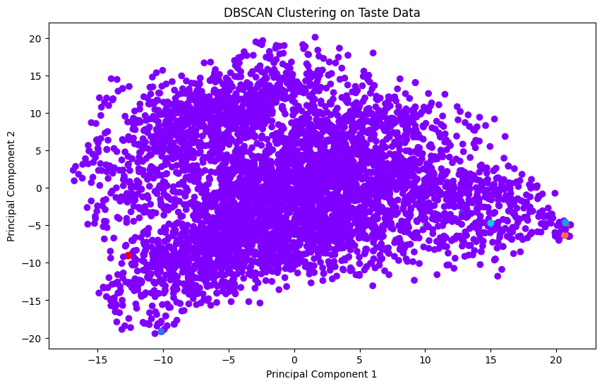

```
Number of clusters found by DBSCAN: 14
Indices of core samples:  [  26   29   57  105  115  181  205  231  308  909  929  933 1087 1533
 1587 1606 1617 1638 1642 1649 1679 1697 1713 1718 1731 1734 1758 1759
 1773 1782 1819 1824 1847 1887 1898 1905 1907 1911 1919 1924 1986 2018
 2279 2543 2545 2547 2567 2570 2572 2582 2613 2703 2772 2782 2855 3201
 3209 3217 3223 3232 3236 3242 3247 3250 3259 3262 3296 3305 3306 3317
 3322 3347 3353 3355 3394 3835 4178 4179 4180 4181 4182 4183 4184 4185
 4186 4187 4327 4426 4428 4436 4440 4469 4473 4587 4619 4627 4654 4709
 4731 5155 5156 5157 5159 5160 5162 5168 5171 5176 5181 5203 5205 5210
 5216 5229 5232 5235 5236]
Copy of each core sample found by training:  [[ 1.28325644e+01 -3.39083373e+00  1.11376448e+00 ...  1.44047733e-18
   8.67218809e-18 -6.19381026e-19]
 [-1.01481333e+01 -1.91933002e+01  3.68858893e+00 ... -2.85971635e-17
   1.21468644e-16  1.05090179e-17]
 [ 2.07127074e+01 -4.64282410e+00  4.19490070e+00 ... -2.15436371e-16
   9.11347907e-17 -3.30809663e-17]
 ...
 [ 2.07127074e+01 -4.64282410e+00  4.19490070e+00 ... -3.76475251e-17
  -1.82318329e-17 -2.54215175e-18]
 [ 2.07127074e+01 -4.64282410e+00  4.19490070e+00 ... -3.76475251e-17
  -1.82318329e-17 -2.54215175e-18]
 [ 2.07127074e+01 -4.64282410e+00  4.19490070e+00 ... -3.76475251e-17
  -1.82318329e-17 -2.54215175e-18]]
Labels:  [-1 -1 -1 ... -1 -1 -1]
Number of features seen during fit:  1107
```

```python
# for the taste data
dbscanTaste = DBSCAN(eps=.2, min_samples=5)
labelsTaste = dbscanTaste.fit_predict(printCompTaste)
n_clusuters_taste = len(set(labelsTaste)) - (1 if -1 in labelsTaste else 0)

#plot
plt.figure(figsize=(10,6))
plt.scatter(printCompTaste[:, 0], printCompTaste[:, 1], c=labelsTaste, cmap='rainbow')
plt.title('DBSCAN Clustering on Taste Data')
plt.xlabel('Principal Component 1')
plt.ylabel('Principal Component 2')
plt.show()

# attributes of the dbscan object
print(f"Number of clusters found by DBSCAN: {n_clusuters_taste}")
print("Indices of core samples: ", dbscanTaste.core_sample_indices_)
print("Copy of each core sample found by training: ", dbscanTaste.components_)
print("Labels: ", dbscanTaste.labels_)
print("Number of features seen during fit: ", dbscanTaste.n_features_in_)
```

Next, we will use hierarchical clustering!

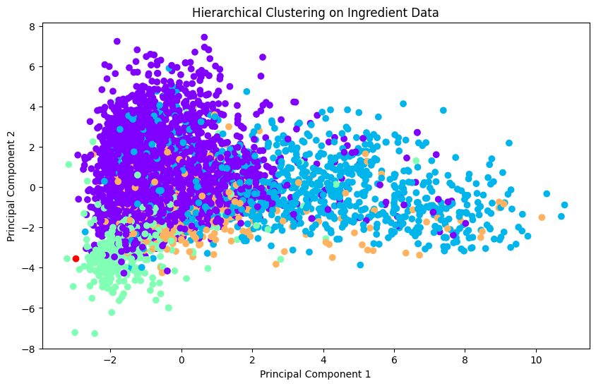

```python
# for Ingredients Data
hierarchicalIngr = AgglomerativeClustering(n_clusters=5).fit(printCompIngr)
labelsIngr_hier = hierarchicalIngr.labels_

#plot
plt.figure(figsize=(10,6))
plt.scatter(printCompIngr[:, 0], printCompIngr[:, 1], c=labelsIngr_hier, cmap='rainbow')
plt.title('Hierarchical Clustering on Ingredient Data')
plt.xlabel('Principal Component 1')
plt.ylabel('Principal Component 2')
plt.show()
```

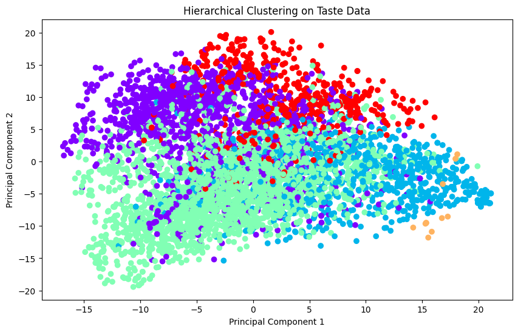

```python
# for Taste Data
hierarchicalTaste = AgglomerativeClustering(n_clusters=5).fit(printCompTaste)
labelsTaste_hier = hierarchicalTaste.labels_

#plot
plt.figure(figsize=(10,6))
plt.scatter(printCompTaste[:, 0], printCompTaste[:, 1], c=labelsTaste_hier, cmap='rainbow')
plt.title('Hierarchical Clustering on Taste Data')
plt.xlabel('Principal Component 1')
plt.ylabel('Principal Component 2')
plt.show()
```

With the help of the Gaussian mixture model maybe we can make that claim!

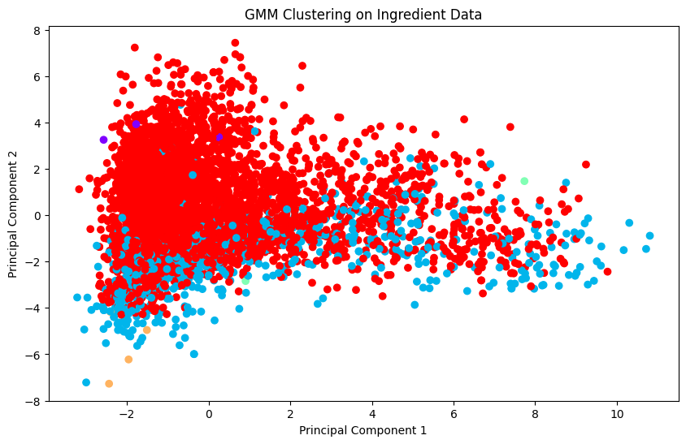

```python
# GMM for Ingredients Data
gmmIngr = GaussianMixture(n_components=5).fit(printCompIngr)
labelsIngr_gmm = gmmIngr.predict(printCompIngr)

#plot
plt.figure(figsize=(10,6))
plt.scatter(printCompIngr[:, 0], printCompIngr[:, 1], c=labelsIngr_gmm, cmap='rainbow')
plt.title('GMM Clustering on Ingredient Data')
plt.xlabel('Principal Component 1')
plt.ylabel('Principal Component 2')
plt.show()
```

Based on the graph, while having a decent elcipse shape, there is significant overlap between the clusters and once again 1 strong cluster compared to the other. With this plot and all of the previous ones, I would assume that there is no strong classification that is occuring within the dataset for ingredients.

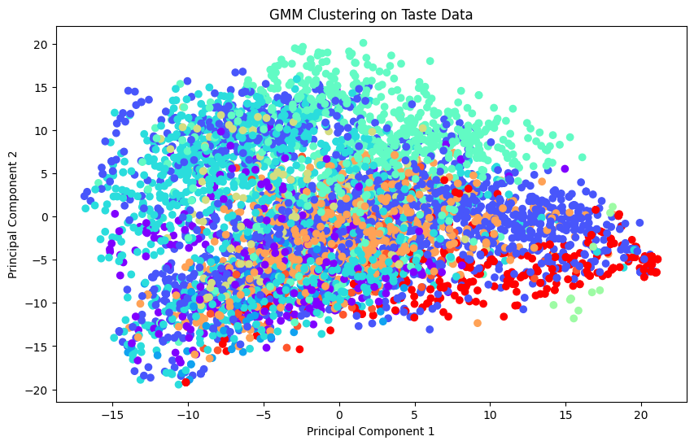

```python
# GMM for Taste Data
gmmTaste = GaussianMixture(n_components=10).fit(printCompTaste)
labelsTaste_gmm = gmmTaste.predict(printCompTaste)

#plot
plt.figure(figsize=(10,6))
plt.scatter(printCompTaste[:, 0], printCompTaste[:, 1], c=labelsTaste_gmm, cmap='rainbow')
plt.title('GMM Clustering on Taste Data')
plt.xlabel('Principal Component 1')
plt.ylabel('Principal Component 2')
plt.show()
```

Due to the large overlap of clusters, we can assume there is not a strong classification ratio. Even though the last graph may have leaned us in that direction, there seems to be one large cluster (purple) that is overlapped by the rest of the clusters and is spread far with little eclipse shape.